# paropt

Konrad Krämer

## How to use paropt

The package paropt is build in order to optimize parameters of ode-systems. The aim is to match the output of the **in silico** solutiuon to previously measured states. The user has to supply an ode-system in the form of a Rcpp-function or as an external pointer to a C++ function. The information about states and parameters are passed as data.frames. In this vignette a predator-prey system is used as example to demonstrate how the functions from ‘paropt’ can be used.

## Using a Rcpp-function

If using a Rcpp-function the following signature has to be fulfilled: ‘Rcpp::NumericVector ode(double t, std::vector params, Rcpp::NumericVector y).’ The first entry defines the time point when the function is called. The second argument defines the parameter which should be optimized. Notably, the parameters are in the same order as in the data.frames containing the information about the boundaries. The last argument is a vector containing the states in the same order as defined in the data.frame containing the state-information. Thus, it is obligatory that the state-derivates in the ode-system are in the same order defined as in the data.frame. Furthermore, it is mandatory that the function return a Rcpp::NumericVector with the same dimension as the input vector containing the states. Naturally, the vector should contain the right hand side of the ode-system.

```cpp
#include <Rcpp.h>

// [[Rcpp::export]]
Rcpp::NumericVector ode_system(double t, std::vector<double> params,
                               Rcpp::NumericVector states) {

  // set dimension of vector which should be returned
  Rcpp::NumericVector states_deriv(2); //two states in the example above (prey and predator)

  // store parameters in variables
  double a = params[0];
  double b = params[1];
  double c = params[2];
  double d = params[3];

  // store states in variables
  double predator = states[0];
  double prey = states[1];

  // the actual ode-system
  double ddtpredator = states_deriv[0] = predator*c*prey - predator*d;
  double ddtprey = states_deriv[1] = prey*a - prey*b*predator;

  return states_deriv;
}

/*** R
path <- system.file("examples", package = "paropt")

# states
df <- read.table(paste(path,"/states_LV.txt", sep = ""), header = TRUE)

# parameter
lb <- data.frame(time = 0, a = 0.8, b = 0.3, c = 0.09, d = 0.09)
ub <- data.frame(time = 0, a = 1.3, b = 0.7, c = 0.4, d = 0.7)

# Optimizing
library(paropt)
set.seed(1)
output <- optimizer(integration_times = df$time, ode_system = ode_system,
                          relative_tolerance = 1e-6, absolute_tolerances = c(1e-8, 1e-8),
                          lb = lb, ub = ub, states = df,
                          npop = 40, ngen = 1000, error = 0.0001, solvertype = "bdf")
output

# Plots
par(mfrow = c(2,1))
plot(df$time, output$States[,1], pch = 19, type = 'l', ylab = "predator", xlab = "time", ylim = c(0, 30))
points(df$time, states$n1, pch = 19, col = "darkred", type = 'p')
legend(80, 30, legend=c("in silico", "measured"),
       col=c("black", "darkred"), lty=1, cex=0.8)
plot(df$time, output$States[,2], pch = 19, type = 'l', ylab = "prey", xlab = "time", ylim = c(0, 65))
points(df$time, states$n2, pch = 19, col = "darkred", type = 'p')
legend(80, 60, legend=c("in silico", "measured"),
       col=c("black", "darkred"), lty=1, cex=0.8)

# Solving
optimized_parameter <- as.data.frame(output$Parameter)
names(optimized_parameter) <- c("time", "a", "b", "c", "d")
output_solver <- solve_ode_system(integration_times = df$time, ode_system = ode_system,
                                  relative_tolerance = 1e-6, absolute_tolerances = c(1e-8, 1e-8),
                                  start = optimized_parameter, states = df, solvertype = "bdf")
output_solver
*/
```

## Using an external pointer to a C++ function

If using an external pointer to a C++ function the following signature is mandatory: int ode(double &t, std::vector& params,std::vector& states). The arguments are in principal the same as in the Rcpp-function approach. However, the right-hand side has to be stored in the input vector states. For instance one could first extract the content of the state vector storing it in suitable variables. Afterwards the vector states can be filled with the right hand side information which is defined by using the before defined variables. The order of the states and parameters has to be the same as in the data.frames in order to calculate the error correctly and use the correct parameters.

**It is crucial that the function is thread-safe!**

```cpp
// [[Rcpp::depends(RcppArmadillo)]]
#include <RcppArmadillo.h>
// [[Rcpp::depends(paropt)]]
// [[Rcpp::plugins(cpp11)]]

typedef int (*OS)(double &t, std::vector<double> &params, std::vector<double> &states);

int ode_system(double &t, std::vector<double> &params, std::vector<double> & states) {

  // do not use any R-Code or R-Objects if the optimzation should run in parallel.
  // Users have to guarantee that the function can be called by several threads in parallel
  // define parameters (vector params contain the parameter in the order as defined in the corresponding textfiles)
  double a = params[0];
  double b = params[1];
  double c = params[2];
  double d = params[3];

  // states have to be in the same order as specified in the textfile "states_LV.txt" (Otherwise the error-calculation does not work)
  double n1 = states[0];
  double n2 = states[1];

  states[0] = n1*c*n2 - n1*d;
  states[1] = n2*a - n2*b*n1;

  return 0;
}


// [[Rcpp::export]]
Rcpp::XPtr<OS> test_optimization() {
  Rcpp::XPtr<OS> xpfun = Rcpp::XPtr<OS>(new OS(&ode_system));

  return xpfun;
}



/*** R
#states
path <- system.file("examples", package = "paropt")
states <- read.table(paste(path,"/states_LV.txt", sep = ""), header = T)

# parameter
lb <- data.frame(time = 0, a = 0.8, b = 0.3, c = 0.09, d = 0.09)
ub <- data.frame(time = 0, a = 1.3, b = 0.7, c = 0.4, d = 0.7)

# Optimizing
library(paropt)
set.seed(1)
df <- optimizer_pointer(integration_times = states$time, ode_sys = test_optimization(),
                        relative_tolerance = 1e-6, absolute_tolerances = c(1e-8, 1e-8),
                       lower = lb, upper = ub, states = states,
                       npop = 40, ngen = 1000, error = 0.0001, solvertype = "bdf")

df
# Plots
par(mfrow = c(2,1))
plot(states$time, df$States[,1], pch = 19, type = 'l', ylab = "predator", xlab = "time", ylim = c(0, 30))
points(states$time, states$n1, pch = 19, col = "darkred", type = 'p')
legend(80, 30, legend=c("in silico", "measured"),
       col=c("black", "darkred"), lty=1, cex=0.8)
plot(states$time, df$States[,2], pch = 19, type = 'l', ylab = "prey", xlab = "time", ylim = c(0, 65))
points(states$time, states$n2, pch = 19, col = "darkred", type = 'p')
legend(80, 60, legend=c("in silico", "measured"),
       col=c("black", "darkred"), lty=1, cex=0.8)

# Solving
optimized_parameter <- as.data.frame(df$Parameter)
names(optimized_parameter) <- c("time", "a", "b", "c", "d")

output_solver <- solve_ode_system_pointer(integration_times = states$time, fctptr = test_optimization(),
                                  relative_tolerance = 1e-6, absolute_tolerances = c(1e-8, 1e-8),
                                  start = optimized_parameter, states = states, solvertype = "bdf")

output_solver
*/
```

# State-input

The information of the states, have to be supplied as a data.frame. It is compulsory that the first column has the name time. This column contains the independent variable across the solver integrate (it has not to be the time. In this document it is always called time). It is followed by the information of the states at the specific time points. Notably, the order of the states is the same as in the ode-system in order to correctly calculate the error. If a state is not availabe at all timepoints use ‘NA’ in order to ignore this state at the specified timepoint for calculating the error. However, the first line below the header cannot contain ‘NA’ as this values are the start values for the ode-solver.

Example for states

| time | predator | prey |
| --- | --- | --- |
| 0 | 10.0000000 | 10.0000000 |
| 2 | 0.5817171 | 0.6475807 |
| 4 | 0.0139678 | 0.7725800 |
| 6 | 0.1339224 | 0.7012095 |
| 8 | 0.8865405 | 0.0900321 |
| 10 | 0.1633466 | 0.8847090 |
| 12 | 0.9216616 | NA |
| 14 | 0.3304055 | 0.1591742 |
| 16 | 0.8988875 | 0.2836523 |
| 18 | 0.0993483 | 0.5206316 |
| 20 | 0.6440035 | 0.7426173 |
| 22 | 0.0416340 | 0.1085562 |
| 24 | 0.2411111 | 0.1737162 |

# Parameter-input

Constant parameters do not change their value during the integration of the ode-system. The boundaries for these parameters have to be defined in the first row. Notably, the first column of the data.frames containing the lower or upper boundaries is the time column. The name ‘time’ is mandatory for this column. If a parameter is not constant at least four different time-points are needed. The information for the parameter at the time-points are feeded in an interpolation-function in order to calculate values at each time-point the ode-system is called. The interpolation is conducted in a wrapper-function around the actual ode-system. Thus, the parameter passed to the ode-system are the already splined values for the specific time-point. For instance if the ode-system is called at t = 3.5 the parameter ‘variable’ is not defined. In this case the parameters have to be interpolated. This is conducted using a Catmull-Rom-Spline. The parameter-vector passed to the ode-system contains already the splined parameters at timepoint t.

Example for the lower boundaries

| time | const | variable |
| --- | --- | --- |
| 0 | 1 | 1 |
| 2 | NA | 2 |
| 4 | NA | 3 |
| 6 | NA | 4 |
| 8 | NA | 5 |
| 10 | NA | 6 |
| 12 | NA | 7 |
| 14 | NA | 8 |
| 16 | NA | 9 |
| 18 | NA | 10 |
| 20 | NA | 11 |
| 22 | NA | 12 |
| 24 | NA | 13 |

Example for the upper boundaries

| time | const | variable |
| --- | --- | --- |
| 0 | 2 | 20 |
| 2 | NA | 20 |
| 4 | NA | 20 |
| 6 | NA | 20 |
| 8 | NA | 20 |
| 10 | NA | 20 |
| 12 | NA | 20 |
| 14 | NA | 20 |
| 16 | NA | 20 |
| 18 | NA | 20 |
| 20 | NA | 20 |
| 22 | NA | 20 |
| 24 | NA | 20 |

# What happens during one evaluation of a parameterset

During the optimization the optimizer creates a bunch of possible solutions within the parameter boundaries. Each solution is passed to the ode-solver which integrate along the time and return the states at the time-points specified in the data.frame containing the state-information. The *in silico* solution is compared to the measured states in order to evaluate the parameterset. The error used is the sum of the absolute differences, between *in silico* and measured states, divided by the number of timepoints.

# Result of simulations

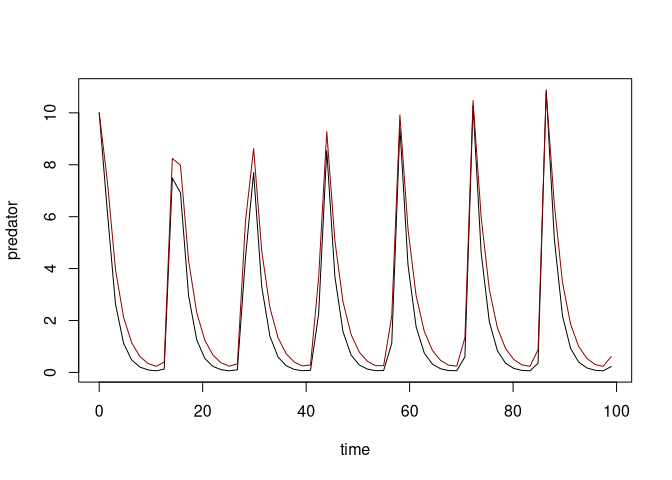

Result for the predator data. In black the in silico values and in red the measured values

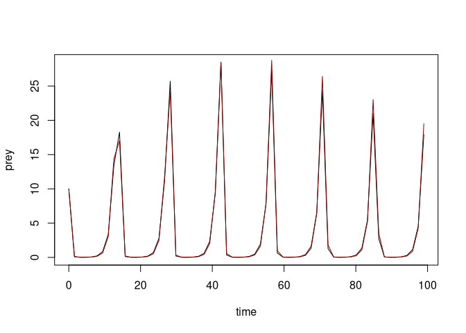

Result for the prey data. In black the in silico values and in red the measured values

## The arguments for function optimizer and optimizer_pointer

```r
optimizer(integration_times, ode_system,
          relative_tolerance, absolute_tolerances,
          lb, ub, states,
          npop, ngen, error, solvertype)
```

The first argument is the time-vector containing either the same information as in the time-column defined in the data.frame containing the states (see Table1) or only a *subset* (it can only be shorted at the end).  
It is mandatory to start with the first entry of the time-column, however it is possible to stop at a certain time-point before the last one. Thus, it is possible to optimize only a part of the problem.

Next argument is the compiled ode-system followed by the relative tolerance and the absolute tolerances are used by the ode-solver. Followed by the data.frames defining the lower and upper boundaries of the parameter. Next the data.frame containing the state information is passed to the function.

In order to optimize the parameters a particle swarm optimizer (PSO) is used. Therefore, the number of particles (npop = 40 is a good starting point for many problems) and the number of generations (ngen) have to be passed to the function. The number of generations defines the maximum number of generations the PSO should run. However, if the PSO finds a suitable parameterset which posess an error below or equal a threshold defined by the user it stops. This threshold is defined by the error-argument.

In principal the optimizer_pointer and solve_ode_system_pointer do the same as the functions optimizer and solve_ode_system. However, they use an external pointer to a C++ function. Thus, they show a better performance. Notably, it was necessary to change the PSO function for optimizer_pointer in order to permit parallelisation. Therefore even with the same seed the results differ between optimizer and optimizer_pointer.

## Particle swarm optimizer (PSO)

This PSO-implementation is a modified version of ‘https://github.com/kthohr/optim’ (for a general overview see Sengupta, Basak, and Peters (2018)). The PSO has several key features. First of all a bunch (number of particles defined by user) of possible parametersets is created within the boundaries defined by the user. Each parameterset is called a particle. All particles together are called the swarm. Each possible parameterset is passed to the solver which integrates the system. The result is used to calculate the error. Thus, each particle has a current solution and a current personal best value. Furthermore, each particle possess a neighberhood which consists of 0-3 other particles (for details see Akman, Akman, and Schaefer (2018)). The PSO uses a combination of its history (personal best value) and the information of the best particle of the neighberhood to change its current value. Notably, in this package a randomly adaptive topology is used. This means, that the neighberhood is recalculated each time when the global best solution (best solution of the entire swarm) has not improved within one generation.

## References

Akman, Devin, Olcay Akman, and Elsa Schaefer. 2018. “Parameter Estimation in Ordinary Differential Equations Modeling via Particle Swarm Optimization.” *Journal of Applied Mathematics* 2018. https://doi.org/10.1155/2018/9160793.

Hindmarsh, Alan C., Peter N. Brown, Keith E. Grant, Steven L. Lee, Radu Serban, Dan E. Shumaker, and Carol S. Woodward. 2005. “SUNDIALS: Suite of nonlinear and differential/algebraic equation solvers.” *ACM Transactions on Mathematical Software* 31 (3): 363–96. https://doi.org/10.1145/1089014.1089020.

Sengupta, Saptarshi, Sanchita Basak, and Richard Peters. 2018. “Particle Swarm Optimization: A Survey of Historical and Recent Developments with Hybridization Perspectives.” *Machine Learning and Knowledge Extraction* 1 (1): 157–91. https://doi.org/10.3390/make1010010.